# Juvenile lifers

Riin Aljas

29/10/2019

*Rendered at 10:31 AM, Oct. 30, 2019*

*Riin Aljas (aljasriin@gmail.com)*

# **MARYLAND**

## What is the racial breakdown of juvenile lifers in each state?

|  | Race | people | pct | total_people | pct_own_race_total | pct_of_total_pop | disparity |
| --- | --- | --- | --- | --- | --- | --- | --- |
| 1 | Asian | 2 | 0.55 | 46 | 4.35 | 0.24 | 0.31 |
| 2 | Black | 282 | 77.69 | 13427 | 2.1 | 69.33 | 8.36 |
| 3 | Hispanic | 17 | 4.68 | 679 | 2.5 | 3.51 | 1.17 |
| 4 | American Indian/Alaska Native | 2 | 0.55 | 103 | 1.94 | 0.53 | 0.02 |
| 5 | Native Hawaiian/Other Pacific Islander | 1 | 0.28 | 13 | 7.69 | 0.07 | 0.21 |
| 6 | Other | 7 | 1.93 | 191 | 3.66 | 0.99 | 0.94 |
| 7 | Unknown | 1 | 0.28 | 29 | 3.45 | 0.15 | 0.13 |
| 8 | White | 51 | 14.05 | 4879 | 1.05 | 25.19 | -11.14 |

When we look at the racial breakdown above, we see that when we compare to the overall prison population, there are disporportionately more black people (**69% of all MD prisoners are black compared to 77% of juveniles**) compared to white people, where the situation is the opposite (**25% of all MD prisoners are white compared to 14% of juveniles**). With hispanic people the difference is small, only 1%.

## Has there been a change since 2016, the date of a key supreme court case, in the number of juvenile lifers in each state? If so, what is the change.

Maryland has only released 3 people so far, hence this question doesn’t apply here. Yet it’s still interesting to see how the numbers have changed in the past.

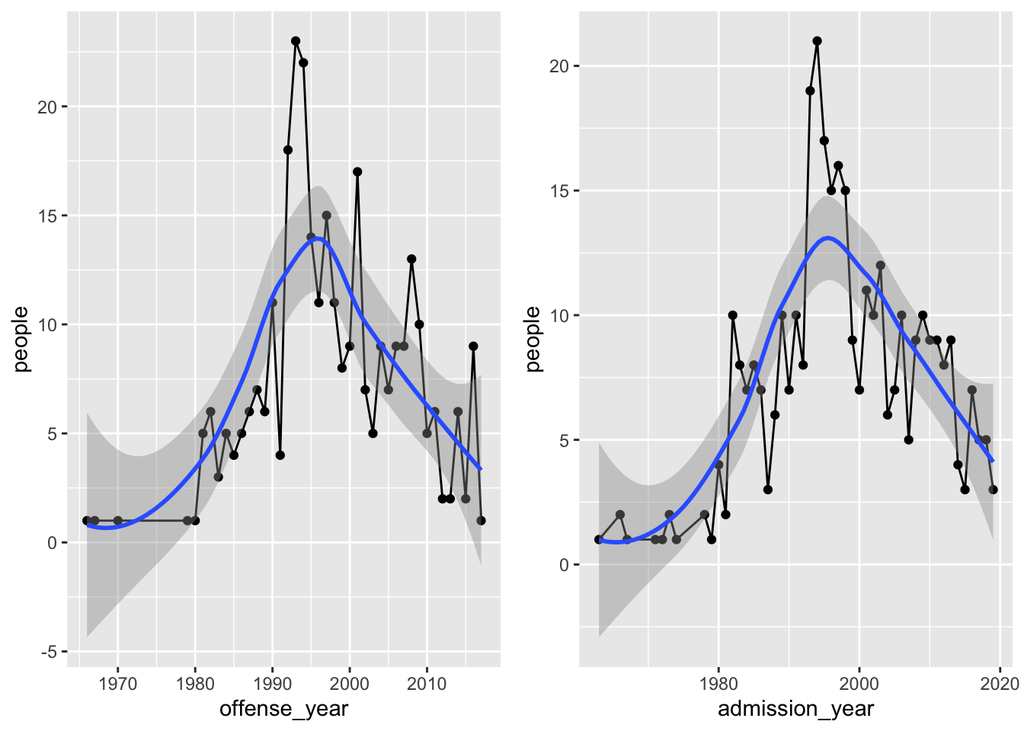

We use both admission dates and offence dates, because MD’s Department of Correction doesn’t have offense dates for all the juveniles, so they use admission dates for some of them. The graphs show the incarceration rate of juvenile “lifers”peaked in the mid-ninenties and started to fall ever since.

*There isn’t a sharp fall in sentencing juveniles to serve life sentences after 2014 amd 2016, but we’re still waiting to hear back from MD about whether they gave us data about all juvenile lifers or lifers with the chance of parole.*

## If there has been a change, has the racial distribution of people affected the same as the racial distribution of the juvenile lifer population as a whole??

Again, Maryland has only released/resentenced three people, so this doesn’t apply. However we can see whether the racial distribution has changed over time.

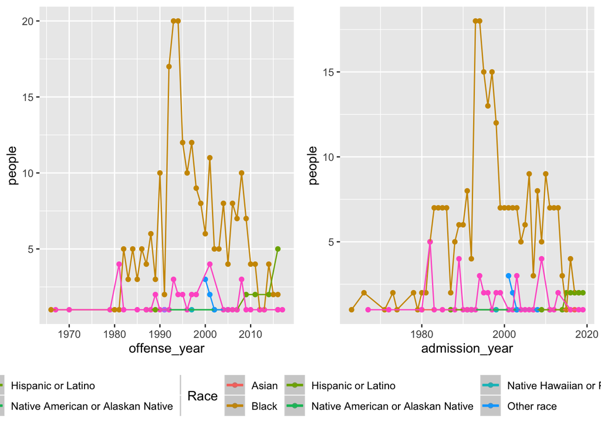

***

## If there has been a change, is there a geographic disparity in who is being affected?**

Doesn’t apply again. But is there any previous disparity among counties?

|  | NAME | people | pct | value | juvenile_per_person |
| --- | --- | --- | --- | --- | --- |
| 1 | Allegany County | 1 | 0.275482093663912 | 70975 | 1.40894681225784e-05 |
| 2 | Anne Arundel County | 15 | 4.13223140495868 | 576031 | 2.60402651940607e-05 |
| 3 | Baltimore City | 130 | 35.8126721763085 | 602495 | 0.000215769425472411 |
| 4 | Baltimore County | 44 | 12.1212121212121 | 828431 | 5.31124499203917e-05 |
| 5 | Caroline County | 2 | 0.550964187327824 | 33304 | 6.00528465049243e-05 |
| 6 | Carroll County | 3 | 0.826446280991736 | 168429 | 1.78116595123168e-05 |
| 7 | Cecil County | 3 | 0.826446280991736 | 102826 | 2.91755003598312e-05 |
| 8 | Charles County | 6 | 1.65289256198347 | 161503 | 3.71510126746872e-05 |
| 9 | Dorchester County | 6 | 1.65289256198347 | 31998 | 0.000187511719482468 |
| 10 | Frederick County | 3 | 0.826446280991736 | 255648 | 1.17348854675178e-05 |

[output cut: 10 more lines]

# PENNSYLVANIA

**What is the overall number of juveniles in each state currently serving a life sentence?**

There are **`521`** juveniles serving a life sentence. **98%** of juvenile prisoners are male.

**What is the racial breakdown of juvenile lifers in each state? Are the racial splits out of proportion to the prison population as a whole, or the state population as a whole?**

**in becoming days I’m planning to see whether this has changed over time**

|  | Race | people | pct | total_people | pct_own_race_total | pct_of_total_pop | disparity |
| --- | --- | --- | --- | --- | --- | --- | --- |
| 1 | Asian | 2 | 0.38 | 46 | 4.35 | 0.24 | 0.14 |
| 2 | Black | 372 | 71.4 | 13427 | 2.77 | 70.55 | 0.85 |
| 3 | Hispanic | 51 | 9.79 | 679 | 7.51 | 3.57 | 6.22 |
| 4 | White | 96 | 18.43 | 4879 | 1.97 | 25.64 | -7.21 |

**Has there been a change since 2016, the date of a key supreme court case, in the number of juvenile lifers in each state?**

The graphs below show how incarceration rate peaked in mdininenties and started to fall in early 2000-s.

Unlike what we saw in Maryland previously, there’s a clear decrease in sentencing juveniles to life sentences after 2014 and 2016 decisions.

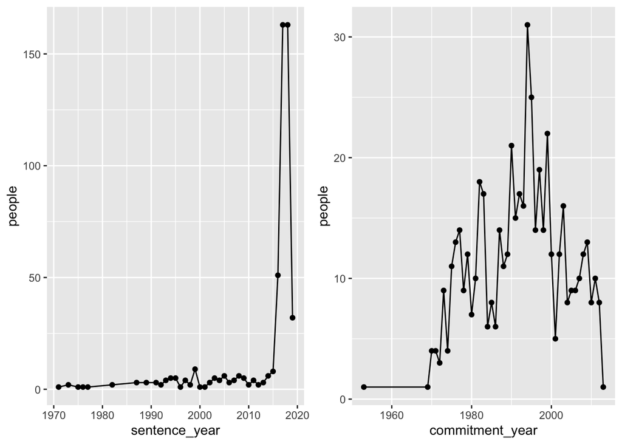

**If there has been a change, has the racial distribution of people affected the same as the racial distribution of the juvenile lifer population as a whole?**

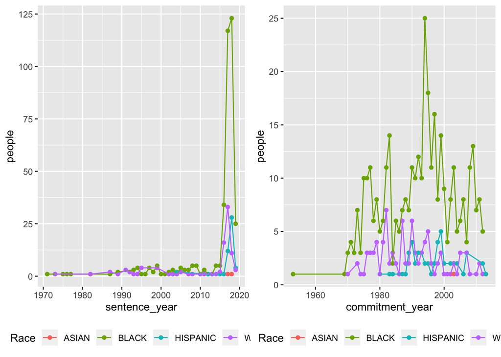

**How many of them have been resentenced and released**

Aronund 82 % of juveniles have been either resentenced to no longer life or released. 15% are waiting to be either resentenced or released. Three people have died and nine (1.7%) have been resentenced but sentenced to serve life in prison.

|  | Status | people | pct |
| --- | --- | --- | --- |
| 1 | Deceased | 3 | 0.58 |
| 2 | Pending | 77 | 14.78 |
| 3 | Released | 209 | 40.12 |
| 4 | Released, then Readmitted | 1 | 0.19 |
| 5 | Resentenced (no longer Life-Life) | 216 | 41.46 |
| 6 | Resentenced (no longer Life-Life)* | 6 | 1.15 |
| 7 | Resentenced to Life-Life | 9 | 1.73 |

Hispanics have been released/resentenced the most, then blacks then whites. For blacks it might come down to the fact that blacks were among the first being released/resentenced (sometimes already early 2000). That doesn’t apply for hispanics though.

|  | Status | nr_black_people | pct_BLACK | nr_white_people | pct_WHITE | nr_hispanic_people | pct_HISPANIC | nr_asian_people | pct_ASIAN |
| --- | --- | --- | --- | --- | --- | --- | --- | --- | --- |
| 1 | Deceased | 1 | 0.27 | 2 | 2.08 |  |  |  |  |
| 2 | Pending | 46 | 12.37 | 27 | 28.12 | 4 | 7.84 |  |  |
| 3 | Released | 160 | 43.01 | 32 | 33.33 | 17 | 33.33 |  |  |
| 4 | Released, then Readmitted | 1 | 0.27 |  |  |  |  |  |  |
| 5 | Resentenced (no longer Life-Life) | 155 | 41.67 | 31 | 32.29 | 28 | 54.9 | 2 | 100 |
| 6 | Resentenced (no longer Life-Life)* | 5 | 1.34 |  |  | 1 | 1.96 |  |  |
| 7 | Resentenced to Life-Life | 4 | 1.08 | 4 | 4.17 | 1 | 1.96 |  |  |

**If there has been a change, is there a geographic disparity in who is being affected?**

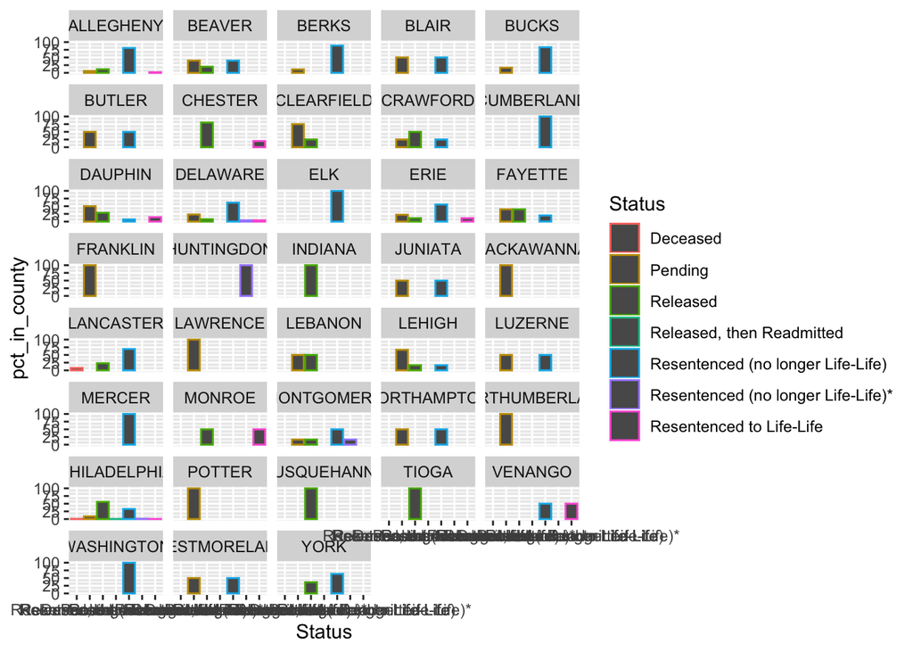

Most of counties with high amount of pending people have small juvenile population to begin with, exceptions are Dauphin and Delaware.

Same goes for the counties with re high % of released peopele, exception being Philadelphia, that has released a lot of people.

Delaware is the exception, having 26 total juveniles but low number of released people. Allegheny has a high % of resentenced people.

## **MICHIGAN**

**What is the overall number of juveniles in each state currently serving a life sentence?**

There are **`368`** juveniles serving a life sentence. **97%** of juvenile prisoners are male.

**What is the racial breakdown of juvenile lifers in each state?**

Michigan differs from Maryland and Pennsylvania, because the racial breakdown is almost entirely in line with the racial breakdwon in total prison population. What is more, unlike MD and PA, it doesn’t have notably less white juveniles compared to overall white population.

|  | Race | people | pct | total_people | pct_own_race_total | pct_of_total_pop | disparity |
| --- | --- | --- | --- | --- | --- | --- | --- |
| 1 | Asian | 2 | 0.54 | 46 | 4.35 | 0.24 | 0.3 |
| 2 | Black | 258 | 70.11 | 13427 | 1.92 | 70.17 | -0.0600000000000023 |
| 3 | Hispanic | 10 | 2.72 | 679 | 1.47 | 3.55 | -0.83 |
| 4 | NA | 1 | 0.27 |  |  |  |  |
| 5 | American Indian/Alaska Native | 1 | 0.27 | 103 | 0.97 | 0.54 | -0.27 |
| 6 | White | 96 | 26.09 | 4879 | 1.97 | 25.5 | 0.59 |

**Has there been a change since 2016, the date of a key supreme court case, in the number of juvenile lifers in each state?**

Similarly to MD and PA, incarceration rate of juvenile lifers peaked in mid-nineties and then started to fall. It’s notable that there isn’t a juvenile who has been sentenced after 2015. In parallel, there’s a steep rise in resentencing after the 2014 and 2016 supreme court decisions.

The graphs show, how the increase in incarceration rates affected black juveniles so much more than white or hispanic youth. This applies for all three states in our analysis.

Overall, half of Michigan juvenile lifers have gotten a resentence. - 7% of all juveniles have been released - 38% have gotten a new sentence instead of life sentence(most of them got either 20-60 or 30-60 years, some 40-60) - 12 % people are either waiting for a set resentence hearing to begin or their decision - 4% got their resentence, but they were again given a life sentence - rest of them, 39%, are serving life and there’s yet no information about their future resentencing

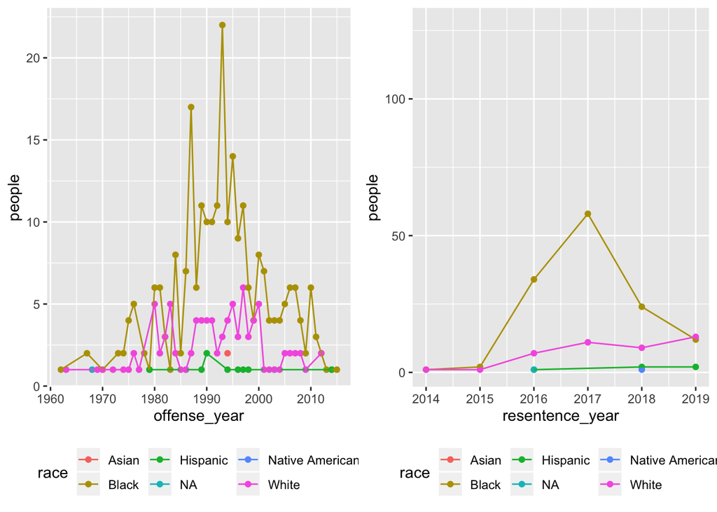

It’s notewrothy, that almost half of people who got resentenced back to life (7 juveniles) are from Kent County. When it comes to nr of juveniles per person, then Kent is 18th, yet with absolute numbers (24 peopl) it’s 4th. So, Kent County doesn’t particularly stand out, so something else might be going on. The offense dates for “re-lifers” are all different, so it’s not one horrific crime. More reporting is needed.

Let’s look into counties more deeply. Graphs below show the status of resentenced juveniles in Michigan counties. The bars show the porportion of resentence decision in comparison to the entire juvenile lifer population in this country. Simply put we see that St Clair and Ottawa have high life-to-life columns, because they only have so little juveniles to begin with. Whereas Macomb and Kent actually stand out by resentencing people back to life more than one would excpect.

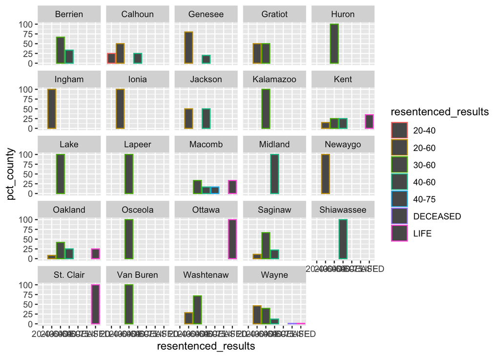

Is it because black people live in more liberal counties or were their trials in 1990s less fair? We migth wanna pull in red or blue counties for the first comparison.

When we look at the ages of released people, we see that there are more old people among black released people.

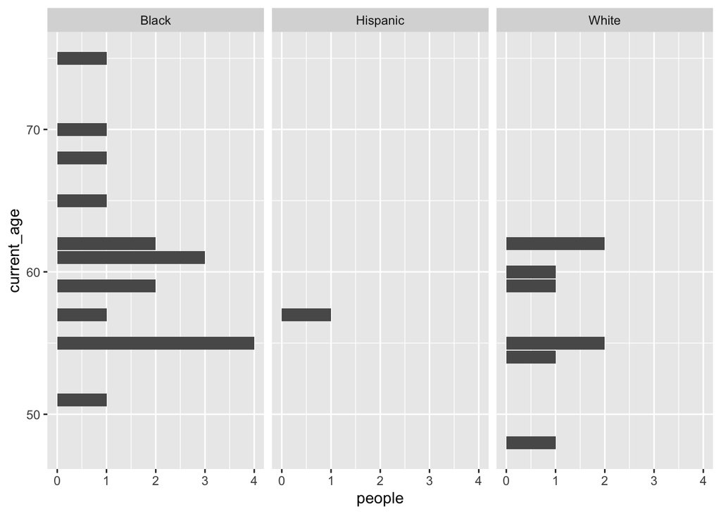